# Statistical analyzes : Simon Couillard

## Master

### Non-paramétrique

|  | BOOST (N=60) | Dream (N=888) | FeNO+RASP-UK (N=74) | Prisma (N=53) | P-value |
| --- | --- | --- | --- | --- | --- |
| Gender_0Female_1Male |  |  |  |  |  |
| Male | 22 (36.7%) | 316 (35.6%) | 41 (55.4%) | 19 (35.8%) | 0.0101 |
| Female | 38 (63.3%) | 572 (64.4%) | 33 (44.6%) | 34 (64.2%) |  |
| BMI |  |  |  |  |  |
| Median [Q1 - Q3] | 27.9 [24.1 - 33.2] | 27.6 [24.2 - 32.1] | 27.9 [24.9 - 32.0] | 28.2 [24.8 - 33.7] | 0.678 |
| Missing | 0 (0%) | 140 (15.8%) | 0 (0%) | 0 (0%) |  |
| ACQ_baseline_score_mean |  |  |  |  |  |
| Median [Q1 - Q3] | 3.60 [3.00 - 4.40] | 2.40 [1.60 - 3.20] | 1.60 [0.600 - 2.20] | 3.60 [2.60 - 4.20] | <0.001 |
| Missing | 0 (0%) | 283 (31.9%) | 0 (0%) | 0 (0%) |  |
| Any_severe_attack_previous_12m_0no_1yes |  |  |  |  |  |
| No | 21 (35.0%) | 0 (0%) | 26 (35.1%) | 13 (24.5%) | <0.001 |
| Yes | 39 (65.0%) | 741 (100%) | 48 (64.9%) | 40 (75.5%) |  |
| Missing | 0 (0%) | 147 (16.6%) | 0 (0%) | 0 (0%) |  |
| Treatment_step |  |  |  |  |  |
| 1 | 0 (0%) | 0 (0%) | 0 (NA%) | 1 (1.9%) | <0.001 |
| 2 | 0 (0%) | 0 (0%) | 0 (NA%) | 3 (5.7%) |  |
| 3 | 0 (0%) | 0 (0%) | 0 (NA%) | 6 (11.3%) |  |
| 4 | 0 (0%) | 0 (0%) | 0 (NA%) | 15 (28.3%) |  |
| 5 | 60 (100%) | 888 (100%) | 0 (NA%) | 28 (52.8%) |  |
| Missing | 0 (0%) | 0 (0%) | 74 (100%) | 0 (0%) |  |
| FEV1_preBD_PCT_Baseline |  |  |  |  |  |
| Median [Q1 - Q3] | 69.5 [53.3 - 85.3] | 60.8 [48.7 - 71.1] | 82.8 [75.7 - 97.6] | 79.7 [66.0 - 88.3] | <0.001 |
| Missing | 0 (0%) | 272 (30.6%) | 0 (0%) | 0 (0%) |  |
| Pre_FEV1_FVC_ratio |  |  |  |  |  |
| Median [Q1 - Q3] | 66.0 [54.8 - 76.0] | 63.2 [54.9 - 72.1] | 70.3 [61.4 - 79.2] | 71.1 [66.6 - 75.3] | <0.001 |
| Missing | 0 (0%) | 272 (30.6%) | 0 (0%) | 0 (0%) |  |
| Blood_Eos_baseline_x10_9_cells_per_L |  |  |  |  |  |
| Median [Q1 - Q3] | 0.0200 [0 - 0.0625] | 0.290 [0.150 - 0.510] | 0.250 [0.133 - 0.498] | 0.210 [0.100 - 0.360] | <0.001 |
| Missing | 0 (0%) | 272 (30.6%) | 0 (0%) | 0 (0%) |  |
| FeNO_baseline_ppb |  |  |  |  |  |
| Median [Q1 - Q3] | 47.5 [18.0 - 80.5] | 31.0 [18.0 - 56.0] | 41.5 [27.3 - 63.0] | 18.0 [11.0 - 37.0] | <0.001 |
| Missing | 0 (0%) | 282 (31.8%) | 0 (0%) | 0 (0%) |  |
| Smoking_0never_1ex_2current |  |  |  |  |  |
| Never | 43 (71.7%) | 590 (79.2%) | 54 (73.0%) | 41 (77.4%) | <0.001 |
| Ex | 0 (0%) | 155 (20.8%) | 17 (23.0%) | 12 (22.6%) |  |
| Current | 0 (0%) | 0 (0%) | 3 (4.1%) | 0 (0%) |  |
| Ex smoker | 17 (28.3%) | 0 (0%) | 0 (0%) | 0 (0%) |  |
| Missing | 0 (0%) | 143 (16.1%) | 0 (0%) | 0 (0%) |  |
| AllergicRhinitis__0no_1yes_9999notknown |  |  |  |  |  |
| No | 52 (86.7%) | 0 (NA%) | 0 (NA%) | 20 (37.7%) | <0.001 |
| Yes | 8 (13.3%) | 0 (NA%) | 0 (NA%) | 33 (62.3%) |  |
| Missing | 0 (0%) | 888 (100%) | 74 (100%) | 0 (0%) |  |
| CRSsNP |  |  |  |  |  |
| No | 59 (98.3%) | 768 (86.5%) | 0 (NA%) | 38 (71.7%) | <0.001 |
| Yes | 1 (1.7%) | 120 (13.5%) | 0 (NA%) | 15 (28.3%) |  |
| Missing | 0 (0%) | 0 (0%) | 74 (100%) | 0 (0%) |  |
| CRSwNP |  |  |  |  |  |
| No | 46 (76.7%) | 822 (92.6%) | 0 (NA%) | 42 (79.2%) | <0.001 |
| Yes | 14 (23.3%) | 66 (7.4%) | 0 (NA%) | 11 (20.8%) |  |
| Missing | 0 (0%) | 0 (0%) | 74 (100%) | 0 (0%) |  |

### Paramétrique

|  | BOOST (N=60) | Dream (N=888) | FeNO+RASP-UK (N=74) | Prisma (N=53) | P-value |
| --- | --- | --- | --- | --- | --- |
| Gender_0Female_1Male |  |  |  |  |  |
| Male | 22 (36.7%) | 316 (35.6%) | 41 (55.4%) | 19 (35.8%) | 0.011 |
| Female | 38 (63.3%) | 572 (64.4%) | 33 (44.6%) | 34 (64.2%) |  |
| BMI |  |  |  |  |  |
| Median [Q1 - Q3] | 27.9 [24.1 - 33.2] | 27.6 [24.2 - 32.1] | 27.9 [24.9 - 32.0] | 28.2 [24.8 - 33.7] | 0.346 |
| Missing | 0 (0%) | 140 (15.8%) | 0 (0%) | 0 (0%) |  |
| ACQ_baseline_score_mean |  |  |  |  |  |
| Median [Q1 - Q3] | 3.60 [3.00 - 4.40] | 2.40 [1.60 - 3.20] | 1.60 [0.600 - 2.20] | 3.60 [2.60 - 4.20] | <0.001 |
| Missing | 0 (0%) | 283 (31.9%) | 0 (0%) | 0 (0%) |  |
| Any_severe_attack_previous_12m_0no_1yes |  |  |  |  |  |
| No | 21 (35.0%) | 0 (0%) | 26 (35.1%) | 13 (24.5%) | <0.001 |
| Yes | 39 (65.0%) | 741 (100%) | 48 (64.9%) | 40 (75.5%) |  |
| Missing | 0 (0%) | 147 (16.6%) | 0 (0%) | 0 (0%) |  |
| Treatment_step |  |  |  |  |  |
| 1 | 0 (0%) | 0 (0%) | 0 (NA%) | 1 (1.9%) | <0.001 |
| 2 | 0 (0%) | 0 (0%) | 0 (NA%) | 3 (5.7%) |  |
| 3 | 0 (0%) | 0 (0%) | 0 (NA%) | 6 (11.3%) |  |
| 4 | 0 (0%) | 0 (0%) | 0 (NA%) | 15 (28.3%) |  |
| 5 | 60 (100%) | 888 (100%) | 0 (NA%) | 28 (52.8%) |  |
| Missing | 0 (0%) | 0 (0%) | 74 (100%) | 0 (0%) |  |
| FEV1_preBD_PCT_Baseline |  |  |  |  |  |
| Median [Q1 - Q3] | 69.5 [53.3 - 85.3] | 60.8 [48.7 - 71.1] | 82.8 [75.7 - 97.6] | 79.7 [66.0 - 88.3] | <0.001 |
| Missing | 0 (0%) | 272 (30.6%) | 0 (0%) | 0 (0%) |  |
| Pre_FEV1_FVC_ratio |  |  |  |  |  |
| Median [Q1 - Q3] | 66.0 [54.8 - 76.0] | 63.2 [54.9 - 72.1] | 70.3 [61.4 - 79.2] | 71.1 [66.6 - 75.3] | <0.001 |
| Missing | 0 (0%) | 272 (30.6%) | 0 (0%) | 0 (0%) |  |
| Blood_Eos_baseline_x10_9_cells_per_L |  |  |  |  |  |
| Median [Q1 - Q3] | 0.0200 [0 - 0.0625] | 0.290 [0.150 - 0.510] | 0.250 [0.133 - 0.498] | 0.210 [0.100 - 0.360] | <0.001 |
| Missing | 0 (0%) | 272 (30.6%) | 0 (0%) | 0 (0%) |  |
| FeNO_baseline_ppb |  |  |  |  |  |
| Median [Q1 - Q3] | 47.5 [18.0 - 80.5] | 31.0 [18.0 - 56.0] | 41.5 [27.3 - 63.0] | 18.0 [11.0 - 37.0] | <0.001 |
| Missing | 0 (0%) | 282 (31.8%) | 0 (0%) | 0 (0%) |  |
| Smoking_0never_1ex_2current |  |  |  |  |  |
| Never | 43 (71.7%) | 590 (79.2%) | 54 (73.0%) | 41 (77.4%) | <0.001 |
| Ex | 0 (0%) | 155 (20.8%) | 17 (23.0%) | 12 (22.6%) |  |
| Current | 0 (0%) | 0 (0%) | 3 (4.1%) | 0 (0%) |  |
| Ex smoker | 17 (28.3%) | 0 (0%) | 0 (0%) | 0 (0%) |  |
| Missing | 0 (0%) | 143 (16.1%) | 0 (0%) | 0 (0%) |  |
| AllergicRhinitis__0no_1yes_9999notknown |  |  |  |  |  |
| No | 52 (86.7%) | 0 (NA%) | 0 (NA%) | 20 (37.7%) | <0.001 |
| Yes | 8 (13.3%) | 0 (NA%) | 0 (NA%) | 33 (62.3%) |  |
| Missing | 0 (0%) | 888 (100%) | 74 (100%) | 0 (0%) |  |
| CRSsNP |  |  |  |  |  |
| No | 59 (98.3%) | 768 (86.5%) | 0 (NA%) | 38 (71.7%) | <0.001 |
| Yes | 1 (1.7%) | 120 (13.5%) | 0 (NA%) | 15 (28.3%) |  |
| Missing | 0 (0%) | 0 (0%) | 74 (100%) | 0 (0%) |  |
| CRSwNP |  |  |  |  |  |
| No | 46 (76.7%) | 822 (92.6%) | 0 (NA%) | 42 (79.2%) | <0.001 |
| Yes | 14 (23.3%) | 66 (7.4%) | 0 (NA%) | 11 (20.8%) |  |
| Missing | 0 (0%) | 0 (0%) | 74 (100%) | 0 (0%) |  |

## PRISMA

|  | Overall (N=53) |
| --- | --- |
| GINA_Step |  |
| 1 | 1 (1.9%) |
| 2 | 3 (5.7%) |
| 3 | 6 (11.3%) |
| 4 | 15 (28.3%) |
| 5 | 28 (52.8%) |
| Age_at_study_enrollment |  |
| Median [Q1 - Q3] | 49.0 [41.0 - 60.0] |
| Sex |  |
| Male | 19 (35.8%) |
| Female | 34 (64.2%) |
| BMI |  |
| Median [Q1 - Q3] | 28.2 [24.8 - 33.7] |
| BloodEOS_Abso |  |
| Median [Q1 - Q3] | 0.210 [0.100 - 0.360] |
| BloodEOS_Abso_log10 |  |
| Median [Q1 - Q3] | -0.678 [-1.00 - -0.444] |
| FeNO |  |
| Median [Q1 - Q3] | 18.0 [11.0 - 37.0] |
| FeNO_log10 |  |
| Median [Q1 - Q3] | 1.26 [1.04 - 1.57] |
| Pre_FEV1_PORC |  |
| Median [Q1 - Q3] | 79.7 [66.0 - 88.3] |
| Pre_FEV1_FVC_ratio |  |
| Median [Q1 - Q3] | 71.1 [66.6 - 75.3] |
| Severe_asthma_attacks_past_12m_cat |  |
| No | 13 (24.5%) |
| Yes | 40 (75.5%) |
| acq5_moy |  |
| Median [Q1 - Q3] | 3.60 [2.60 - 4.20] |
| V2_V1_Post_FEV1_L |  |
| Median [Q1 - Q3] | 0.0300 [-0.0400 - 0.160] |

## Oracle DREAM

### Complete

|  | Overall (N=888) |
| --- | --- |
| Mepo_placebo |  |
| Placebo | 158 (25.5%) |
| Mepo | 461 (74.5%) |
| Missing | 269 (30.3%) |
| Gender_0Female_1Male |  |
| Male | 316 (35.6%) |
| Female | 572 (64.4%) |
| BMI |  |
| Median [Q1 - Q3] | 27.6 [24.2 - 32.1] |
| Missing | 140 (15.8%) |
| ACQ_baseline_score_mean |  |
| Median [Q1 - Q3] | 2.40 [1.60 - 3.20] |
| Missing | 283 (31.9%) |
| Any_severe_attack_previous_12m_0no_1yes |  |
| No | 0 (0%) |
| Yes | 741 (100%) |
| Missing | 147 (16.6%) |
| Treatment_step |  |
| 1 | 0 (0%) |
| 2 | 0 (0%) |
| 3 | 0 (0%) |
| 4 | 0 (0%) |
| 5 | 888 (100%) |
| FEV1_preBD_PCT_Baseline |  |
| Median [Q1 - Q3] | 60.8 [48.7 - 71.1] |
| Missing | 272 (30.6%) |
| Pre_FEV1_FVC_ratio |  |
| Median [Q1 - Q3] | 63.2 [54.9 - 72.1] |
| Missing | 272 (30.6%) |
| Blood_Eos_baseline_x10_9_cells_per_L |  |
| Median [Q1 - Q3] | 0.290 [0.150 - 0.510] |
| Missing | 272 (30.6%) |
| FeNO_baseline_ppb |  |
| Median [Q1 - Q3] | 31.0 [18.0 - 56.0] |
| Missing | 282 (31.8%) |
| Smoking_0never_1ex_2current |  |
| Never | 590 (79.2%) |
| Ex | 155 (20.8%) |
| Current | 0 (0%) |
| Missing | 143 (16.1%) |
| AllergicRhinitis__0no_1yes_9999notknown |  |
| No | 0 (NA%) |
| Yes | 0 (NA%) |
| Missing | 888 (100%) |
| CRSsNP |  |
| No | 768 (86.5%) |
| Yes | 120 (13.5%) |
| CRSwNP |  |
| No | 822 (92.6%) |
| Yes | 66 (7.4%) |
| T2_composite |  |
| T2-Low/Low | 75 (12.4%) |
| T2-Mid | 377 (62.1%) |
| T2-High/High | 155 (25.5%) |
| Missing | 281 (31.6%) |

### Mepo vs placebo

#### Non-paramétrique

|  | Placebo (N=158) | Mepo (N=461) | P-value |
| --- | --- | --- | --- |
| Gender_0Female_1Male |  |  |  |
| Male | 60 (38.0%) | 171 (37.1%) | 0.849 |
| Female | 98 (62.0%) | 290 (62.9%) |  |
| BMI |  |  |  |
| Median [Q1 - Q3] | 26.7 [24.1 - 31.2] | 27.7 [24.1 - 32.2] | 0.447 |
| Missing | 1 (0.6%) | 0 (0%) |  |
| ACQ_baseline_score_mean |  |  |  |
| Median [Q1 - Q3] | 2.60 [1.80 - 3.20] | 2.40 [1.40 - 3.20] | 0.0679 |
| Missing | 5 (3.2%) | 9 (2.0%) |  |
| Any_severe_attack_previous_12m_0no_1yes |  |  |  |
| No | 0 (0%) | 0 (0%) | 1 |
| Yes | 157 (100%) | 461 (100%) |  |
| Missing | 1 (0.6%) | 0 (0%) |  |
| Treatment_step |  |  |  |
| 1 | 0 (0%) | 0 (0%) | 1 |
| 2 | 0 (0%) | 0 (0%) |  |
| 3 | 0 (0%) | 0 (0%) |  |
| 4 | 0 (0%) | 0 (0%) |  |
| 5 | 158 (100%) | 461 (100%) |  |
| FEV1_preBD_PCT_Baseline |  |  |  |
| Median [Q1 - Q3] | 61.4 [47.4 - 69.7] | 60.5 [49.1 - 71.6] | 0.645 |
| Missing | 3 (1.9%) | 0 (0%) |  |
| Pre_FEV1_FVC_ratio |  |  |  |
| Median [Q1 - Q3] | 61.4 [54.1 - 70.6] | 63.7 [55.0 - 72.3] | 0.49 |
| Missing | 3 (1.9%) | 0 (0%) |  |
| Blood_Eos_baseline_x10_9_cells_per_L |  |  |  |
| Median [Q1 - Q3] | 0.340 [0.160 - 0.610] | 0.270 [0.150 - 0.490] | 0.129 |
| Missing | 3 (1.9%) | 0 (0%) |  |
| FeNO_baseline_ppb |  |  |  |
| Median [Q1 - Q3] | 33.0 [18.5 - 58.5] | 30.0 [18.0 - 54.0] | 0.312 |
| Missing | 7 (4.4%) | 6 (1.3%) |  |
| Smoking_0never_1ex_2current |  |  |  |
| Never | 123 (78.3%) | 362 (78.5%) | 1 |
| Ex | 34 (21.7%) | 99 (21.5%) |  |
| Current | 0 (0%) | 0 (0%) |  |
| Missing | 1 (0.6%) | 0 (0%) |  |
| AllergicRhinitis__0no_1yes_9999notknown |  |  |  |
| No | 0 (NA%) | 0 (NA%) | 1 |
| Yes | 0 (NA%) | 0 (NA%) |  |
| Missing | 158 (100%) | 461 (100%) |  |
| CRSsNP |  |  |  |
| No | 129 (81.6%) | 394 (85.5%) | 0.254 |
| Yes | 29 (18.4%) | 67 (14.5%) |  |
| CRSwNP |  |  |  |
| No | 141 (89.2%) | 420 (91.1%) | 0.527 |
| Yes | 17 (10.8%) | 41 (8.9%) |  |
| T2_composite |  |  |  |
| T2-Low/Low | 18 (11.9%) | 57 (12.5%) | 0.0151 |
| T2-Mid | 81 (53.6%) | 296 (64.9%) |  |
| T2-High/High | 52 (34.4%) | 103 (22.6%) |  |
| Missing | 7 (4.4%) | 5 (1.1%) |  |

#### Paramétrique

|  | Placebo (N=158) | Mepo (N=461) | P-value |
| --- | --- | --- | --- |
| Gender_0Female_1Male |  |  |  |
| Male | 60 (38.0%) | 171 (37.1%) | 0.849 |
| Female | 98 (62.0%) | 290 (62.9%) |  |
| BMI |  |  |  |
| Median [Q1 - Q3] | 26.7 [24.1 - 31.2] | 27.7 [24.1 - 32.2] | 0.79 |
| Missing | 1 (0.6%) | 0 (0%) |  |
| ACQ_baseline_score_mean |  |  |  |
| Median [Q1 - Q3] | 2.60 [1.80 - 3.20] | 2.40 [1.40 - 3.20] | 0.0293 |
| Missing | 5 (3.2%) | 9 (2.0%) |  |
| Any_severe_attack_previous_12m_0no_1yes |  |  |  |
| No | 0 (0%) | 0 (0%) | 1 |
| Yes | 157 (100%) | 461 (100%) |  |
| Missing | 1 (0.6%) | 0 (0%) |  |
| Treatment_step |  |  |  |
| 1 | 0 (0%) | 0 (0%) | 1 |
| 2 | 0 (0%) | 0 (0%) |  |
| 3 | 0 (0%) | 0 (0%) |  |
| 4 | 0 (0%) | 0 (0%) |  |
| 5 | 158 (100%) | 461 (100%) |  |
| FEV1_preBD_PCT_Baseline |  |  |  |
| Median [Q1 - Q3] | 61.4 [47.4 - 69.7] | 60.5 [49.1 - 71.6] | 0.576 |
| Missing | 3 (1.9%) | 0 (0%) |  |
| Pre_FEV1_FVC_ratio |  |  |  |
| Median [Q1 - Q3] | 61.4 [54.1 - 70.6] | 63.7 [55.0 - 72.3] | 0.544 |
| Missing | 3 (1.9%) | 0 (0%) |  |
| Blood_Eos_baseline_x10_9_cells_per_L |  |  |  |
| Median [Q1 - Q3] | 0.340 [0.160 - 0.610] | 0.270 [0.150 - 0.490] | 0.188 |
| Missing | 3 (1.9%) | 0 (0%) |  |
| FeNO_baseline_ppb |  |  |  |
| Median [Q1 - Q3] | 33.0 [18.5 - 58.5] | 30.0 [18.0 - 54.0] | 0.201 |
| Missing | 7 (4.4%) | 6 (1.3%) |  |
| Smoking_0never_1ex_2current |  |  |  |
| Never | 123 (78.3%) | 362 (78.5%) | 1 |
| Ex | 34 (21.7%) | 99 (21.5%) |  |
| Current | 0 (0%) | 0 (0%) |  |
| Missing | 1 (0.6%) | 0 (0%) |  |
| AllergicRhinitis__0no_1yes_9999notknown |  |  |  |
| No | 0 (NA%) | 0 (NA%) | 1 |
| Yes | 0 (NA%) | 0 (NA%) |  |
| Missing | 158 (100%) | 461 (100%) |  |
| CRSsNP |  |  |  |
| No | 129 (81.6%) | 394 (85.5%) | 0.254 |
| Yes | 29 (18.4%) | 67 (14.5%) |  |
| CRSwNP |  |  |  |
| No | 141 (89.2%) | 420 (91.1%) | 0.527 |
| Yes | 17 (10.8%) | 41 (8.9%) |  |
| T2_composite |  |  |  |
| T2-Low/Low | 18 (11.9%) | 57 (12.5%) | 0.0151 |
| T2-Mid | 81 (53.6%) | 296 (64.9%) |  |
| T2-High/High | 52 (34.4%) | 103 (22.6%) |  |
| Missing | 7 (4.4%) | 5 (1.1%) |  |

## ORACLE2

### Full

|  | Overall (N=6513) |
| --- | --- |
| Enrolled_Trial_name |  |
| AZISAST | 54 (0.8%) |
| BENRAP2B | 211 (3.2%) |
| CAPTAIN | 1218 (18.7%) |
| COSTA | 145 (2.2%) |
| DREAM | 155 (2.4%) |
| DRI12544 | 155 (2.4%) |
| EXTRA | 420 (6.4%) |
| LAVOLTA_1 | 362 (5.6%) |
| LAVOLTA_2 | 354 (5.4%) |
| LUSTER_1 | 298 (4.6%) |
| LUSTER_2 | 287 (4.4%) |
| LUTE | 66 (1.0%) |
| MILLY | 112 (1.7%) |
| NAVIGATOR | 517 (7.9%) |
| Novel_START | 218 (3.3%) |
| PACT | 16 (0.2%) |
| PATHWAY | 133 (2.0%) |
| PRACTICAL | 307 (4.7%) |
| QUEST | 634 (9.7%) |
| STRATOS_1 | 388 (6.0%) |
| STRATOS_2 | 413 (6.3%) |
| VERSE | 50 (0.8%) |

### Any ACQ

|  | Overall (N=750) |
| --- | --- |
| Enrolled_Trial_name |  |
| AZISAST | 54 (7.2%) |
| DREAM | 155 (20.7%) |
| Novel_START | 218 (29.1%) |
| PACT | 16 (2.1%) |
| PRACTICAL | 307 (40.9%) |

## FeNO

|  | Overall (N=34) |
| --- | --- |
| AgeD0 |  |
| Median [Q1 - Q3] | 50.5 [37.0 - 62.3] |
| Sex0M1F |  |
| Male | 15 (44.1%) |
| Female | 19 (55.9%) |
| BMI |  |
| Median [Q1 - Q3] | 26.0 [23.9 - 29.8] |
| Blood_Eos_optimised |  |
| Median [Q1 - Q3] | 0.250 [0.190 - 0.505] |
| FeNO_optimised |  |
| Median [Q1 - Q3] | 44.5 [34.3 - 63.0] |
| FEV1_PCTpredicted_optimised |  |
| Median [Q1 - Q3] | 91.5 [78.9 - 105] |
| FEV1_FVC_ratio_optimised |  |
| Median [Q1 - Q3] | 74.3 [66.2 - 82.6] |
| ACQ_optimised |  |
| Median [Q1 - Q3] | 1.70 [0.800 - 2.35] |
| Previous_asthma_attack_yesno |  |
| No | 10 (29.4%) |
| Yes | 24 (70.6%) |
| Sp_Eos_optimised |  |
| Median [Q1 - Q3] | 2.85 [1.25 - 19.9] |
| Missing | 20 (58.8%) |
| Eotaxin-3_Optimised_sputm |  |
| Median [Q1 - Q3] | 117 [50.1 - 255] |
| Missing | 17 (50.0%) |
| IFNgamma_Optimised_sputm |  |
| Median [Q1 - Q3] | 0.301 [0.171 - 0.437] |
| Missing | 17 (50.0%) |
| IL13_Optimised_sputm |  |
| Median [Q1 - Q3] | 8.25 [6.45 - 11.4] |
| Missing | 13 (38.2%) |
| IL33_Optimised_sputm |  |
| Median [Q1 - Q3] | 0.649 [0.296 - 1.51] |
| Missing | 13 (38.2%) |
| IL4_Optimised_sputm |  |
| Median [Q1 - Q3] | 0.216 [0.104 - 0.951] |
| Missing | 13 (38.2%) |
| IL5_Optimised_sputm |  |
| Median [Q1 - Q3] | 3.23 [1.37 - 5.30] |
| Missing | 13 (38.2%) |
| TARC_Optimised_sputm |  |
| Median [Q1 - Q3] | 24.9 [8.65 - 40.8] |
| Missing | 17 (50.0%) |
| TNFalpha_Optimised_sputm |  |
| Median [Q1 - Q3] | 0.890 [0.183 - 3.16] |
| Missing | 17 (50.0%) |
| TSLP_Optimised_sputm |  |
| Median [Q1 - Q3] | 6.32 [2.96 - 9.38] |
| Missing | 13 (38.2%) |
| LTE4_Optimised_sputm |  |
| Median [Q1 - Q3] | 82.2 [50.9 - 247] |
| Missing | 13 (38.2%) |
| PGD2_Optimised_sputm |  |
| Median [Q1 - Q3] | 132 [85.2 - 221] |
| Missing | 13 (38.2%) |

## RASP-UK

|  | Overall (N=40) |
| --- | --- |
| AgeD0 |  |
| Median [Q1 - Q3] | 57.0 [49.8 - 62.3] |
| Sex0M1F |  |
| Male | 26 (65.0%) |
| Female | 14 (35.0%) |
| BMI |  |
| Median [Q1 - Q3] | 28.4 [26.3 - 36.9] |
| Blood_Eos_optimised |  |
| Median [Q1 - Q3] | 0.255 [0.100 - 0.395] |
| FeNO_optimised |  |
| Median [Q1 - Q3] | 37.3 [19.8 - 62.0] |
| FEV1_PCTpredicted_optimised |  |
| Median [Q1 - Q3] | 80.5 [74.0 - 90.5] |
| FEV1_FVC_ratio_optimised |  |
| Median [Q1 - Q3] | 65.3 [60.5 - 73.6] |
| ACQ_optimised |  |
| Median [Q1 - Q3] | 1.20 [0.550 - 2.20] |
| Previous_asthma_attack_yesno |  |
| No | 16 (40.0%) |
| Yes | 24 (60.0%) |
| Sp_Eos_optimised |  |
| Median [Q1 - Q3] | 3.25 [0.575 - 17.0] |
| Missing | 5 (12.5%) |
| Eotaxin-3_Optimised_sputm |  |
| Median [Q1 - Q3] | 149 [23.7 - 431] |
| Missing | 1 (2.5%) |
| IFNgamma_Optimised_sputm |  |
| Median [Q1 - Q3] | 0.465 [0.171 - 1.69] |
| Missing | 1 (2.5%) |
| IL13_Optimised_sputm |  |
| Median [Q1 - Q3] | 6.88 [4.04 - 11.6] |
| Missing | 1 (2.5%) |
| IL33_Optimised_sputm |  |
| Median [Q1 - Q3] | 1.28 [0.689 - 2.71] |
| Missing | 1 (2.5%) |
| IL4_Optimised_sputm |  |
| Median [Q1 - Q3] | 0.419 [0.149 - 0.912] |
| Missing | 1 (2.5%) |
| IL5_Optimised_sputm |  |
| Median [Q1 - Q3] | 5.95 [1.87 - 15.1] |
| Missing | 1 (2.5%) |
| TARC_Optimised_sputm |  |
| Median [Q1 - Q3] | 56.9 [18.4 - 106] |
| Missing | 1 (2.5%) |
| TNFalpha_Optimised_sputm |  |
| Median [Q1 - Q3] | 3.30 [1.15 - 9.42] |
| Missing | 1 (2.5%) |
| TSLP_Optimised_sputm |  |
| Median [Q1 - Q3] | 9.20 [2.22 - 21.2] |
| Missing | 1 (2.5%) |
| LTE4_Optimised_sputm |  |
| Median [Q1 - Q3] | 123 [36.4 - 369] |
| Missing | 4 (10.0%) |
| PGD2_Optimised_sputm |  |
| Median [Q1 - Q3] | 275 [203 - 452] |
| Missing | 5 (12.5%) |

## FeNo + RASP-UK

|  | Overall (N=74) |
| --- | --- |
| AgeD0 |  |
| Median [Q1 - Q3] | 55.0 [46.0 - 62.8] |
| Sex0M1F |  |
| Male | 41 (55.4%) |
| Female | 33 (44.6%) |
| BMI |  |
| Median [Q1 - Q3] | 27.9 [24.9 - 32.0] |
| Blood_Eos_optimised |  |
| Median [Q1 - Q3] | 0.250 [0.133 - 0.498] |
| FeNO_optimised |  |
| Median [Q1 - Q3] | 41.5 [27.3 - 63.0] |
| FEV1_PCTpredicted_optimised |  |
| Median [Q1 - Q3] | 82.8 [75.7 - 97.6] |
| FEV1_FVC_ratio_optimised |  |
| Median [Q1 - Q3] | 70.3 [61.4 - 79.2] |
| ACQ_optimised |  |
| Median [Q1 - Q3] | 1.60 [0.600 - 2.20] |
| Previous_asthma_attack_yesno |  |
| No | 26 (35.1%) |
| Yes | 48 (64.9%) |
| Sp_Eos_optimised |  |
| Median [Q1 - Q3] | 3.25 [0.750 - 19.1] |
| Missing | 25 (33.8%) |
| Eotaxin-3_Optimised_sputm |  |
| Median [Q1 - Q3] | 133 [23.9 - 366] |
| Missing | 18 (24.3%) |
| IFNgamma_Optimised_sputm |  |
| Median [Q1 - Q3] | 0.395 [0.171 - 1.47] |
| Missing | 18 (24.3%) |
| IL13_Optimised_sputm |  |
| Median [Q1 - Q3] | 7.29 [6.03 - 11.6] |
| Missing | 14 (18.9%) |
| IL33_Optimised_sputm |  |
| Median [Q1 - Q3] | 1.09 [0.296 - 2.19] |
| Missing | 14 (18.9%) |
| IL4_Optimised_sputm |  |
| Median [Q1 - Q3] | 0.302 [0.104 - 0.960] |
| Missing | 14 (18.9%) |
| IL5_Optimised_sputm |  |
| Median [Q1 - Q3] | 4.67 [1.72 - 11.4] |
| Missing | 14 (18.9%) |
| TARC_Optimised_sputm |  |
| Median [Q1 - Q3] | 36.1 [17.2 - 91.8] |
| Missing | 18 (24.3%) |
| TNFalpha_Optimised_sputm |  |
| Median [Q1 - Q3] | 2.55 [0.797 - 7.29] |
| Missing | 18 (24.3%) |
| TSLP_Optimised_sputm |  |
| Median [Q1 - Q3] | 6.69 [2.40 - 13.0] |
| Missing | 14 (18.9%) |
| LTE4_Optimised_sputm |  |
| Median [Q1 - Q3] | 103 [41.7 - 332] |
| Missing | 17 (23.0%) |
| PGD2_Optimised_sputm |  |
| Median [Q1 - Q3] | 222 [133 - 404] |
| Missing | 18 (24.3%) |

## BOOST

|  | Overall (N=60) |
| --- | --- |
| Age |  |
| Median [Q1 - Q3] | 56.0 [48.0 - 64.0] |
| Sex |  |
| Male | 22 (36.7%) |
| Female | 38 (63.3%) |
| BMI |  |
| Median [Q1 - Q3] | 27.9 [24.1 - 33.2] |
| Gina_step |  |
| 5 | 60 (100%) |
| acq_attack |  |
| Median [Q1 - Q3] | 3.60 [3.00 - 4.40] |
| CRSsNP |  |
| No | 59 (98.3%) |
| Yes | 1 (1.7%) |
| CRSwNP |  |
| No | 46 (76.7%) |
| Yes | 14 (23.3%) |
| Allergic_rhinitis |  |
| No | 52 (86.7%) |
| Yes | 8 (13.3%) |
| smoking_status |  |
| Never | 43 (71.7%) |
| Ex smoker | 17 (28.3%) |
| fev1_pct_attack |  |
| Median [Q1 - Q3] | 69.5 [53.3 - 85.3] |
| fev1_fvc_attack |  |
| Median [Q1 - Q3] | 66.0 [54.8 - 76.0] |
| blood_eos_attack |  |
| Median [Q1 - Q3] | 0.0200 [0 - 0.0625] |
| BEC_log10 |  |
| Median [Q1 - Q3] | -0.569 [-0.602 - -0.505] |
| feno_attack |  |
| Median [Q1 - Q3] | 47.5 [18.0 - 80.5] |
| FeNO_log10 |  |
| Median [Q1 - Q3] | 1.67 [1.26 - 1.91] |
| delta |  |
| Median [Q1 - Q3] | 0.120 [-0.118 - 0.405] |
| Missing | 2 (3.3%) |

## MasterV2

### Non-paramétrique

|  | ORACLE2 - Full (N=6513) | ORACLE2 - Any ACQ (N=750) | DREAM - Placebo (N=158) | DREAM - Mepo (N=461) | SA-OIT (N=74) | PRISMA (N=53) | BOOST (N=60) | P-value |
| --- | --- | --- | --- | --- | --- | --- | --- | --- |
| Gender_0Female_1Male |  |  |  |  |  |  |  |  |
| Male | 2372 (36.4%) | 328 (43.7%) | 60 (38.0%) | 171 (37.1%) | 41 (55.4%) | 19 (35.8%) | 22 (36.7%) | <0.001 |
| Female | 4141 (63.6%) | 422 (56.3%) | 98 (62.0%) | 290 (62.9%) | 33 (44.6%) | 34 (64.2%) | 38 (63.3%) |  |
| BMI |  |  |  |  |  |  |  |  |
| Median [Q1 - Q3] | 28.2 [25.0 - 31.2] | 26.5 [23.6 - 30.4] | 26.7 [24.1 - 31.2] | 27.7 [24.1 - 32.2] | 27.9 [24.9 - 32.0] | 28.2 [24.8 - 33.7] | 27.9 [24.1 - 33.2] | <0.001 |
| Missing | 0 (0%) | 0 (0%) | 1 (0.6%) | 0 (0%) | 0 (0%) | 0 (0%) | 0 (0%) |  |
| ACQ_baseline_score_mean |  |  |  |  |  |  |  |  |
| Median [Q1 - Q3] | 2.40 [1.80 - 3.00] | 1.20 [0.600 - 2.00] | 2.60 [1.80 - 3.20] | 2.40 [1.40 - 3.20] | 1.60 [0.600 - 2.20] | 3.60 [2.60 - 4.20] | 3.60 [3.00 - 4.40] | <0.001 |
| Missing | 0 (0%) | 0 (0%) | 5 (3.2%) | 9 (2.0%) | 0 (0%) | 0 (0%) | 0 (0%) |  |
| ACQ_below_1.5 |  |  |  |  |  |  |  |  |
| No | 5555 (85.3%) | 295 (39.3%) | 124 (81.0%) | 335 (74.1%) | 39 (52.7%) | 50 (94.3%) | 60 (100%) | <0.001 |
| Yes | 958 (14.7%) | 455 (60.7%) | 29 (19.0%) | 117 (25.9%) | 35 (47.3%) | 3 (5.7%) | 0 (0%) |  |
| Missing | 0 (0%) | 0 (0%) | 5 (3.2%) | 9 (2.0%) | 0 (0%) | 0 (0%) | 0 (0%) |  |
| Any_severe_attack_previous_12m_0no_1yes |  |  |  |  |  |  |  |  |
| No | 1303 (20.0%) | 484 (64.5%) | 0 (0%) | 0 (0%) | 26 (35.1%) | 13 (24.5%) | 21 (35.0%) | <0.001 |
| Yes | 5210 (80.0%) | 266 (35.5%) | 157 (100%) | 461 (100%) | 48 (64.9%) | 40 (75.5%) | 39 (65.0%) |  |
| Missing | 0 (0%) | 0 (0%) | 1 (0.6%) | 0 (0%) | 0 (0%) | 0 (0%) | 0 (0%) |  |
| Treatment_step |  |  |  |  |  |  |  |  |
| 1 | 226 (3.5%) | 226 (30.1%) | 0 (0%) | 0 (0%) | 0 (NA%) | 1 (1.9%) | 0 (0%) | <0.001 |
| 2 | 315 (4.8%) | 315 (42.0%) | 0 (0%) | 0 (0%) | 0 (NA%) | 3 (5.7%) | 0 (0%) |  |
| 3 | 859 (13.2%) | 0 (0%) | 0 (0%) | 0 (0%) | 0 (NA%) | 6 (11.3%) | 0 (0%) |  |
| 4 | 2555 (39.2%) | 0 (0%) | 0 (0%) | 0 (0%) | 0 (NA%) | 15 (28.3%) | 0 (0%) |  |
| 5 | 2558 (39.3%) | 209 (27.9%) | 158 (100%) | 461 (100%) | 0 (NA%) | 28 (52.8%) | 60 (100%) |  |
| Missing | 0 (0%) | 0 (0%) | 0 (0%) | 0 (0%) | 74 (100%) | 0 (0%) | 0 (0%) |  |
| FEV1_preBD_PCT_Baseline |  |  |  |  |  |  |  |  |
| Median [Q1 - Q3] | 64.0 [53.0 - 73.9] | 78.3 [65.0 - 91.0] | 61.4 [47.4 - 69.7] | 60.5 [49.1 - 71.6] | 82.8 [75.7 - 97.6] | 79.7 [66.0 - 88.3] | 69.5 [53.3 - 85.3] | <0.001 |
| Missing | 0 (0%) | 0 (0%) | 3 (1.9%) | 0 (0%) | 0 (0%) | 0 (0%) | 0 (0%) |  |
| Pre_FEV1_FVC_ratio |  |  |  |  |  |  |  |  |
| Median [Q1 - Q3] | 64.1 [56.0 - 72.1] | 67.9 [58.6 - 75.0] | 61.4 [54.1 - 70.6] | 63.7 [55.0 - 72.3] | 70.3 [61.4 - 79.2] | 71.1 [66.6 - 75.3] | 66.0 [54.8 - 76.0] | <0.001 |
| Missing | 0 (0%) | 0 (0%) | 3 (1.9%) | 0 (0%) | 0 (0%) | 0 (0%) | 0 (0%) |  |
| Blood_Eos_baseline_x10_9_cells_per_L |  |  |  |  |  |  |  |  |
| Median [Q1 - Q3] | 0.250 [0.140 - 0.420] | 0.250 [0.150 - 0.390] | 0.340 [0.160 - 0.610] | 0.270 [0.150 - 0.490] | 0.250 [0.133 - 0.498] | 0.210 [0.100 - 0.360] | 0.0200 [0 - 0.0625] | <0.001 |
| Missing | 0 (0%) | 0 (0%) | 3 (1.9%) | 0 (0%) | 0 (0%) | 0 (0%) | 0 (0%) |  |
| FeNO_baseline_ppb |  |  |  |  |  |  |  |  |
| Median [Q1 - Q3] | 23.0 [14.0 - 42.0] | 30.4 [18.0 - 59.8] | 33.0 [18.5 - 58.5] | 30.0 [18.0 - 54.0] | 41.5 [27.3 - 63.0] | 18.0 [11.0 - 37.0] | 47.5 [18.0 - 80.5] | <0.001 |
| Missing | 0 (0%) | 0 (0%) | 7 (4.4%) | 6 (1.3%) | 0 (0%) | 0 (0%) | 0 (0%) |  |
| Smoking_0never_1ex_2current |  |  |  |  |  |  |  |  |
| Never | 5298 (81.3%) | 540 (72.0%) | 123 (78.3%) | 362 (78.5%) | 54 (73.0%) | 41 (77.4%) | 43 (71.7%) | <0.001 |
| Ex | 1175 (18.0%) | 174 (23.2%) | 34 (21.7%) | 99 (21.5%) | 17 (23.0%) | 12 (22.6%) | 17 (28.3%) |  |
| Current | 40 (0.6%) | 36 (4.8%) | 0 (0%) | 0 (0%) | 3 (4.1%) | 0 (0%) | 0 (0%) |  |
| Missing | 0 (0%) | 0 (0%) | 1 (0.6%) | 0 (0%) | 0 (0%) | 0 (0%) | 0 (0%) |  |
| AllergicRhinitis__0no_1yes_9999notknown |  |  |  |  |  |  |  |  |
| No | 3557 (54.6%) | 588 (78.4%) | 0 (NA%) | 0 (NA%) | 0 (NA%) | 20 (37.7%) | 52 (86.7%) | <0.001 |
| Yes | 2956 (45.4%) | 162 (21.6%) | 0 (NA%) | 0 (NA%) | 0 (NA%) | 33 (62.3%) | 8 (13.3%) |  |
| Missing | 0 (0%) | 0 (0%) | 158 (100%) | 461 (100%) | 74 (100%) | 0 (0%) | 0 (0%) |  |
| CRSsNP |  |  |  |  |  |  |  |  |
| No | 5861 (90.0%) | 695 (92.7%) | 129 (81.6%) | 394 (85.5%) | 0 (NA%) | 38 (71.7%) | 59 (98.3%) | <0.001 |
| Yes | 652 (10.0%) | 55 (7.3%) | 29 (18.4%) | 67 (14.5%) | 0 (NA%) | 15 (28.3%) | 1 (1.7%) |  |
| Missing | 0 (0%) | 0 (0%) | 0 (0%) | 0 (0%) | 74 (100%) | 0 (0%) | 0 (0%) |  |
| CRSwNP |  |  |  |  |  |  |  |  |
| No | 5190 (79.7%) | 256 (34.1%) | 141 (89.2%) | 420 (91.1%) | 0 (NA%) | 42 (79.2%) | 46 (76.7%) | <0.001 |
| Yes | 1323 (20.3%) | 494 (65.9%) | 17 (10.8%) | 41 (8.9%) | 0 (NA%) | 11 (20.8%) | 14 (23.3%) |  |
| Missing | 0 (0%) | 0 (0%) | 0 (0%) | 0 (0%) | 74 (100%) | 0 (0%) | 0 (0%) |  |

### Paramétrique

|  | ORACLE2 - Full (N=6513) | ORACLE2 - Any ACQ (N=750) | DREAM - Placebo (N=158) | DREAM - Mepo (N=461) | SA-OIT (N=74) | PRISMA (N=53) | BOOST (N=60) | P-value |
| --- | --- | --- | --- | --- | --- | --- | --- | --- |
| Gender_0Female_1Male |  |  |  |  |  |  |  |  |
| Male | 2372 (36.4%) | 328 (43.7%) | 60 (38.0%) | 171 (37.1%) | 41 (55.4%) | 19 (35.8%) | 22 (36.7%) | <0.001 |
| Female | 4141 (63.6%) | 422 (56.3%) | 98 (62.0%) | 290 (62.9%) | 33 (44.6%) | 34 (64.2%) | 38 (63.3%) |  |
| BMI |  |  |  |  |  |  |  |  |
| Median [Q1 - Q3] | 28.2 [25.0 - 31.2] | 26.5 [23.6 - 30.4] | 26.7 [24.1 - 31.2] | 27.7 [24.1 - 32.2] | 27.9 [24.9 - 32.0] | 28.2 [24.8 - 33.7] | 27.9 [24.1 - 33.2] | <0.001 |
| Missing | 0 (0%) | 0 (0%) | 1 (0.6%) | 0 (0%) | 0 (0%) | 0 (0%) | 0 (0%) |  |
| ACQ_baseline_score_mean |  |  |  |  |  |  |  |  |
| Median [Q1 - Q3] | 2.40 [1.80 - 3.00] | 1.20 [0.600 - 2.00] | 2.60 [1.80 - 3.20] | 2.40 [1.40 - 3.20] | 1.60 [0.600 - 2.20] | 3.60 [2.60 - 4.20] | 3.60 [3.00 - 4.40] | <0.001 |
| Missing | 0 (0%) | 0 (0%) | 5 (3.2%) | 9 (2.0%) | 0 (0%) | 0 (0%) | 0 (0%) |  |
| Any_severe_attack_previous_12m_0no_1yes |  |  |  |  |  |  |  |  |
| No | 1303 (20.0%) | 484 (64.5%) | 0 (0%) | 0 (0%) | 26 (35.1%) | 13 (24.5%) | 21 (35.0%) | <0.001 |
| Yes | 5210 (80.0%) | 266 (35.5%) | 157 (100%) | 461 (100%) | 48 (64.9%) | 40 (75.5%) | 39 (65.0%) |  |
| Missing | 0 (0%) | 0 (0%) | 1 (0.6%) | 0 (0%) | 0 (0%) | 0 (0%) | 0 (0%) |  |
| Treatment_step |  |  |  |  |  |  |  |  |
| 1 | 226 (3.5%) | 226 (30.1%) | 0 (0%) | 0 (0%) | 0 (NA%) | 1 (1.9%) | 0 (0%) | <0.001 |
| 2 | 315 (4.8%) | 315 (42.0%) | 0 (0%) | 0 (0%) | 0 (NA%) | 3 (5.7%) | 0 (0%) |  |
| 3 | 859 (13.2%) | 0 (0%) | 0 (0%) | 0 (0%) | 0 (NA%) | 6 (11.3%) | 0 (0%) |  |
| 4 | 2555 (39.2%) | 0 (0%) | 0 (0%) | 0 (0%) | 0 (NA%) | 15 (28.3%) | 0 (0%) |  |
| 5 | 2558 (39.3%) | 209 (27.9%) | 158 (100%) | 461 (100%) | 0 (NA%) | 28 (52.8%) | 60 (100%) |  |
| Missing | 0 (0%) | 0 (0%) | 0 (0%) | 0 (0%) | 74 (100%) | 0 (0%) | 0 (0%) |  |
| FEV1_preBD_PCT_Baseline |  |  |  |  |  |  |  |  |
| Median [Q1 - Q3] | 64.0 [53.0 - 73.9] | 78.3 [65.0 - 91.0] | 61.4 [47.4 - 69.7] | 60.5 [49.1 - 71.6] | 82.8 [75.7 - 97.6] | 79.7 [66.0 - 88.3] | 69.5 [53.3 - 85.3] | <0.001 |
| Missing | 0 (0%) | 0 (0%) | 3 (1.9%) | 0 (0%) | 0 (0%) | 0 (0%) | 0 (0%) |  |
| Pre_FEV1_FVC_ratio |  |  |  |  |  |  |  |  |
| Median [Q1 - Q3] | 64.1 [56.0 - 72.1] | 67.9 [58.6 - 75.0] | 61.4 [54.1 - 70.6] | 63.7 [55.0 - 72.3] | 70.3 [61.4 - 79.2] | 71.1 [66.6 - 75.3] | 66.0 [54.8 - 76.0] | <0.001 |
| Missing | 0 (0%) | 0 (0%) | 3 (1.9%) | 0 (0%) | 0 (0%) | 0 (0%) | 0 (0%) |  |
| Blood_Eos_baseline_x10_9_cells_per_L |  |  |  |  |  |  |  |  |
| Median [Q1 - Q3] | 0.250 [0.140 - 0.420] | 0.250 [0.150 - 0.390] | 0.340 [0.160 - 0.610] | 0.270 [0.150 - 0.490] | 0.250 [0.133 - 0.498] | 0.210 [0.100 - 0.360] | 0.0200 [0 - 0.0625] | <0.001 |
| Missing | 0 (0%) | 0 (0%) | 3 (1.9%) | 0 (0%) | 0 (0%) | 0 (0%) | 0 (0%) |  |
| FeNO_baseline_ppb |  |  |  |  |  |  |  |  |
| Median [Q1 - Q3] | 23.0 [14.0 - 42.0] | 30.4 [18.0 - 59.8] | 33.0 [18.5 - 58.5] | 30.0 [18.0 - 54.0] | 41.5 [27.3 - 63.0] | 18.0 [11.0 - 37.0] | 47.5 [18.0 - 80.5] | <0.001 |
| Missing | 0 (0%) | 0 (0%) | 7 (4.4%) | 6 (1.3%) | 0 (0%) | 0 (0%) | 0 (0%) |  |
| Smoking_0never_1ex_2current |  |  |  |  |  |  |  |  |
| Never | 5298 (81.3%) | 540 (72.0%) | 123 (78.3%) | 362 (78.5%) | 54 (73.0%) | 41 (77.4%) | 43 (71.7%) | <0.001 |
| Ex | 1175 (18.0%) | 174 (23.2%) | 34 (21.7%) | 99 (21.5%) | 17 (23.0%) | 12 (22.6%) | 17 (28.3%) |  |
| Current | 40 (0.6%) | 36 (4.8%) | 0 (0%) | 0 (0%) | 3 (4.1%) | 0 (0%) | 0 (0%) |  |
| Missing | 0 (0%) | 0 (0%) | 1 (0.6%) | 0 (0%) | 0 (0%) | 0 (0%) | 0 (0%) |  |
| AllergicRhinitis__0no_1yes_9999notknown |  |  |  |  |  |  |  |  |
| No | 3557 (54.6%) | 588 (78.4%) | 0 (NA%) | 0 (NA%) | 0 (NA%) | 20 (37.7%) | 52 (86.7%) | <0.001 |
| Yes | 2956 (45.4%) | 162 (21.6%) | 0 (NA%) | 0 (NA%) | 0 (NA%) | 33 (62.3%) | 8 (13.3%) |  |
| Missing | 0 (0%) | 0 (0%) | 158 (100%) | 461 (100%) | 74 (100%) | 0 (0%) | 0 (0%) |  |
| CRSsNP |  |  |  |  |  |  |  |  |
| No | 5861 (90.0%) | 695 (92.7%) | 129 (81.6%) | 394 (85.5%) | 0 (NA%) | 38 (71.7%) | 59 (98.3%) | <0.001 |
| Yes | 652 (10.0%) | 55 (7.3%) | 29 (18.4%) | 67 (14.5%) | 0 (NA%) | 15 (28.3%) | 1 (1.7%) |  |
| Missing | 0 (0%) | 0 (0%) | 0 (0%) | 0 (0%) | 74 (100%) | 0 (0%) | 0 (0%) |  |
| CRSwNP |  |  |  |  |  |  |  |  |
| No | 5190 (79.7%) | 256 (34.1%) | 141 (89.2%) | 420 (91.1%) | 0 (NA%) | 42 (79.2%) | 46 (76.7%) | <0.001 |
| Yes | 1323 (20.3%) | 494 (65.9%) | 17 (10.8%) | 41 (8.9%) | 0 (NA%) | 11 (20.8%) | 14 (23.3%) |  |
| Missing | 0 (0%) | 0 (0%) | 0 (0%) | 0 (0%) | 74 (100%) | 0 (0%) | 0 (0%) |  |

# Spline Curves Analysis: ACQ-5 Mean Score vs Treatment Response

## PRISMA

### Unadjusted

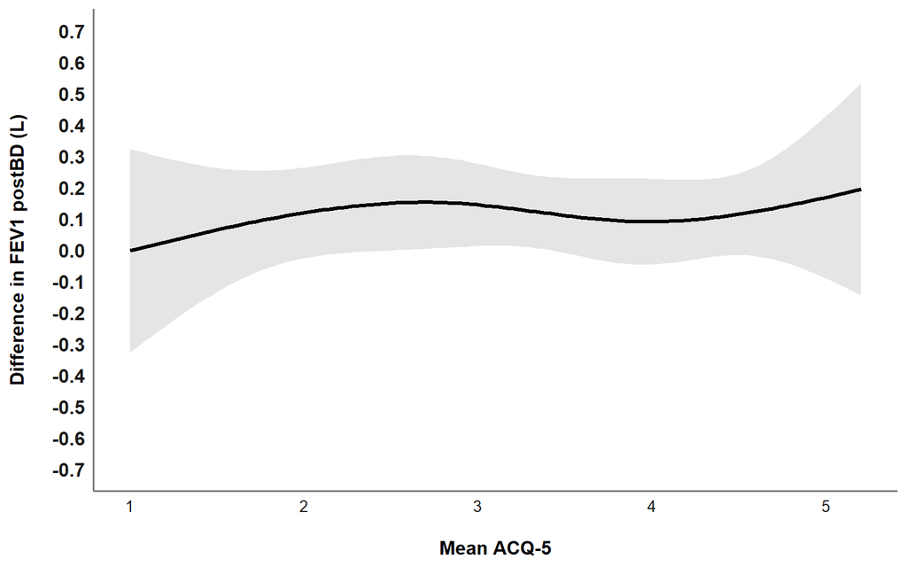

### Adjusted v1

Adjusted for BEC, FeNO and FEV1 V1 (Post_FEV1_L).

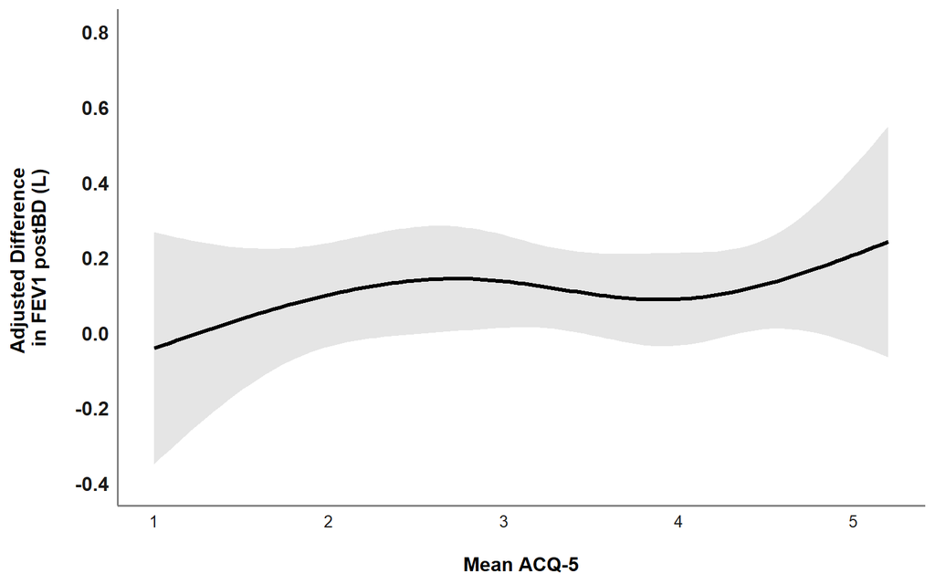

```
## Since column 1 of mat contains values below 0, linreg has been set to TRUE.
```

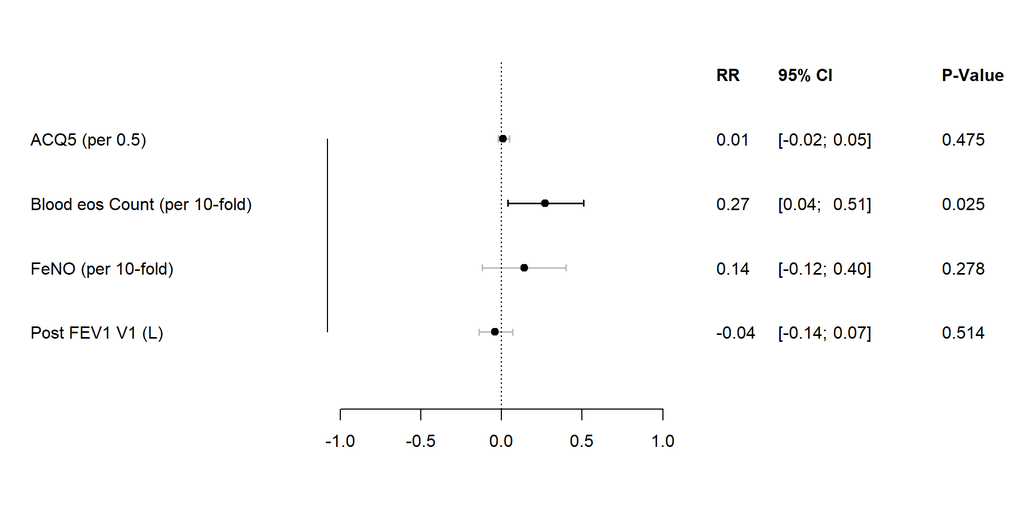

### T2 composite

Adjusted only for FEV1 V1 (Post_FEV1_L) and T2 composite.

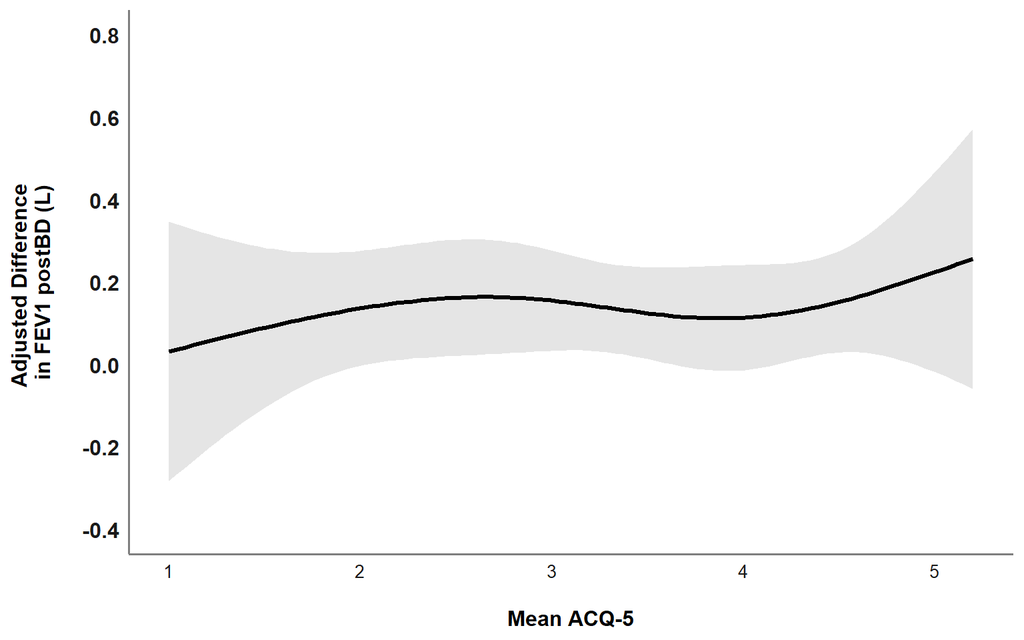

```
## Since column 1 of mat contains values below 0, linreg has been set to TRUE.
```

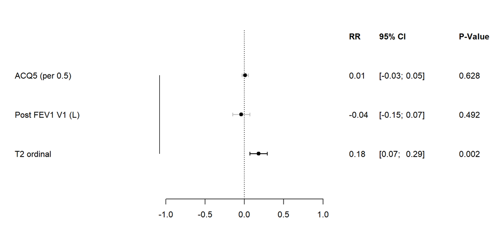

## BOOST

### Unadjusted

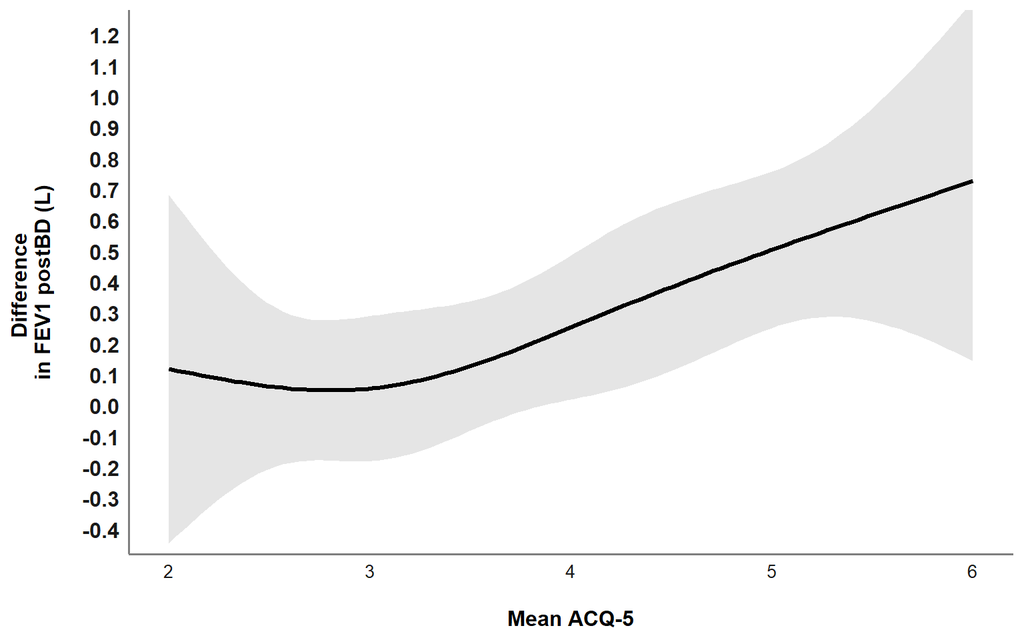

### Adjusted v1

Adjusted for BEC, FeNO and FEV1 V1 (fev1_attack).

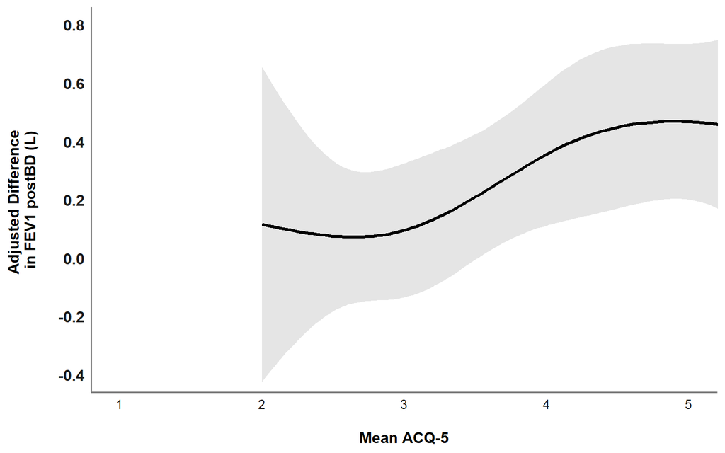

```
## Since column 1 of mat contains values below 0, linreg has been set to TRUE.
```

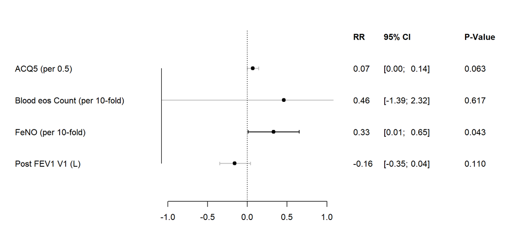

## Oracle DREAM

### Unadjusted

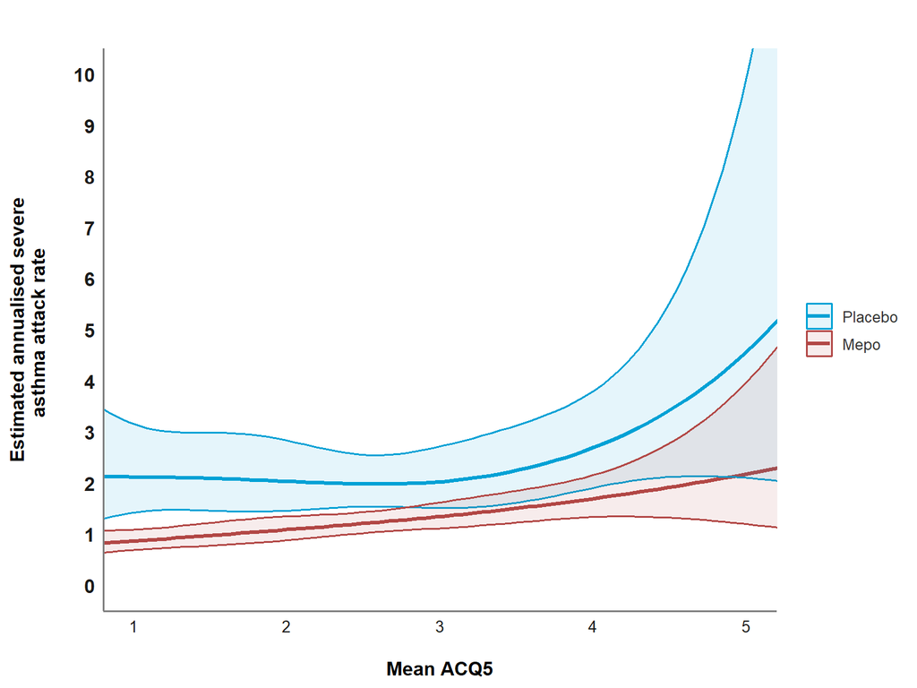

### Adjusted - v1

GINA steps = 5 for all observations and no data for Allergic Rhinitis, variables weren’t included in the final model.

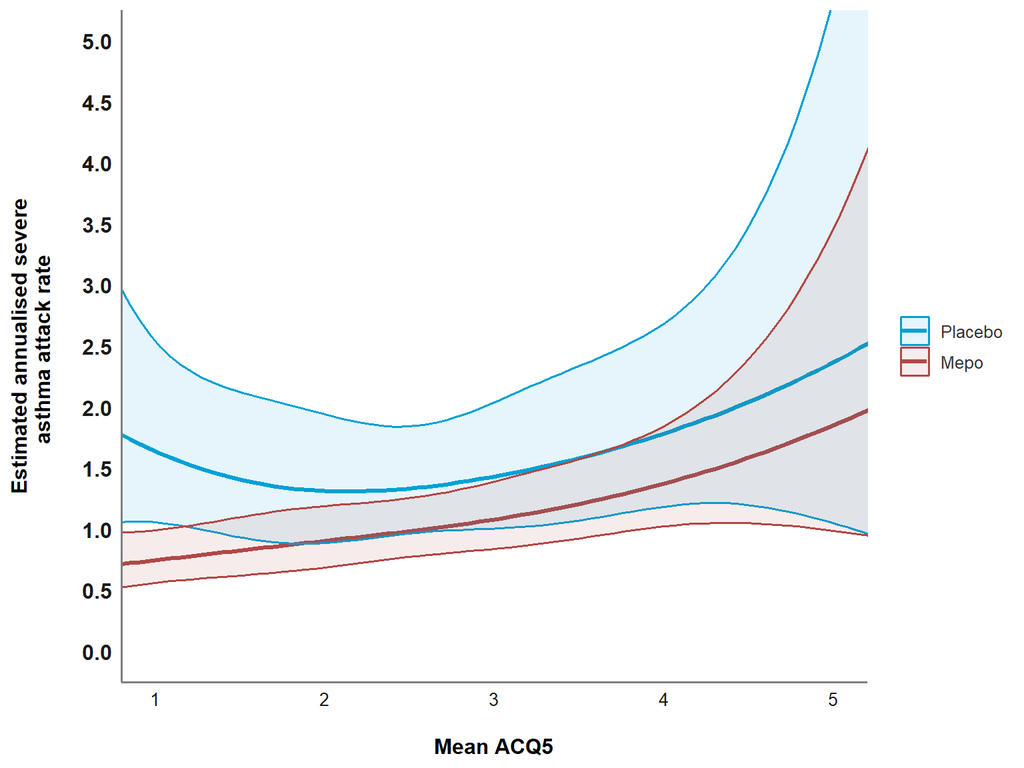

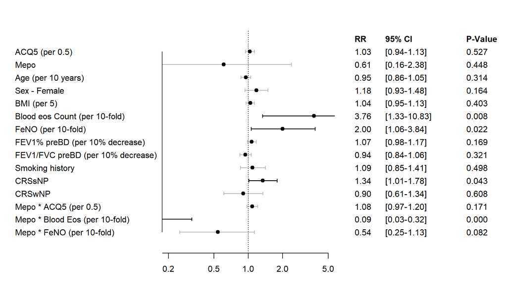

### Adjusted - T2 composite

GINA steps = 5 for all observations and no data for Allergic Rhinitis, variables weren’t included in the final model.

Includes T2_composite (T2 Low/Low, T2-Mid, T2-High/High) treated as an ordinal variable where it replaces BEC × FeNO.

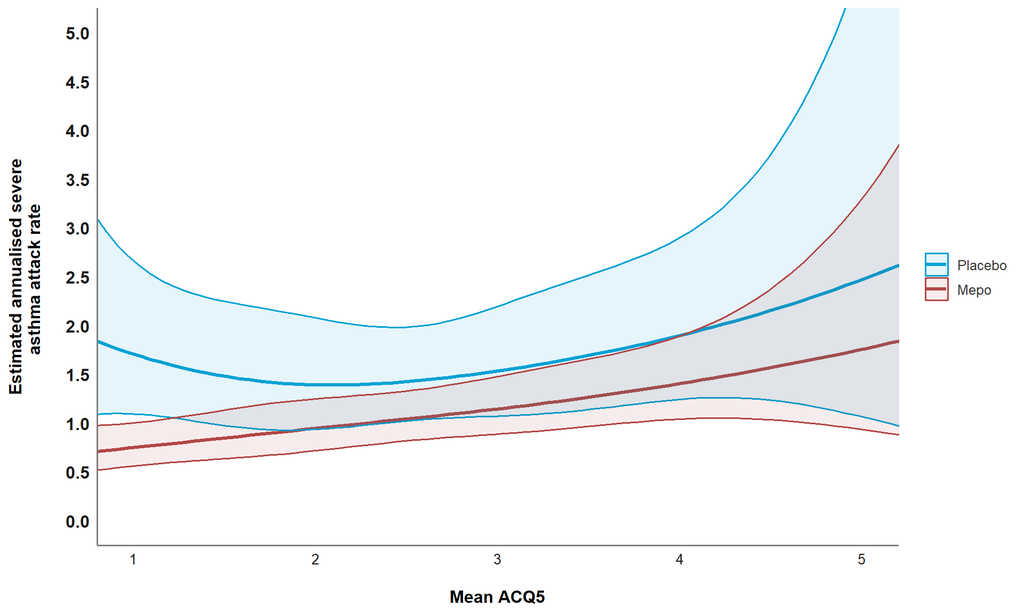

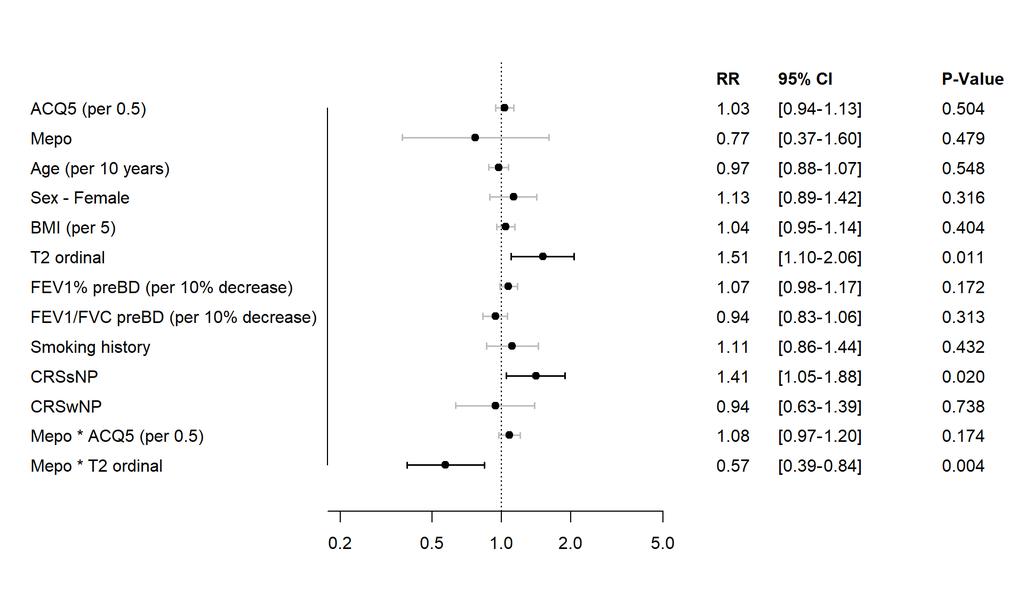

# Forest Plots: Baseline ACQ-5 Mean Score vs Clinical Parameters and Translational Parameters

## Univariable

### PRISMA

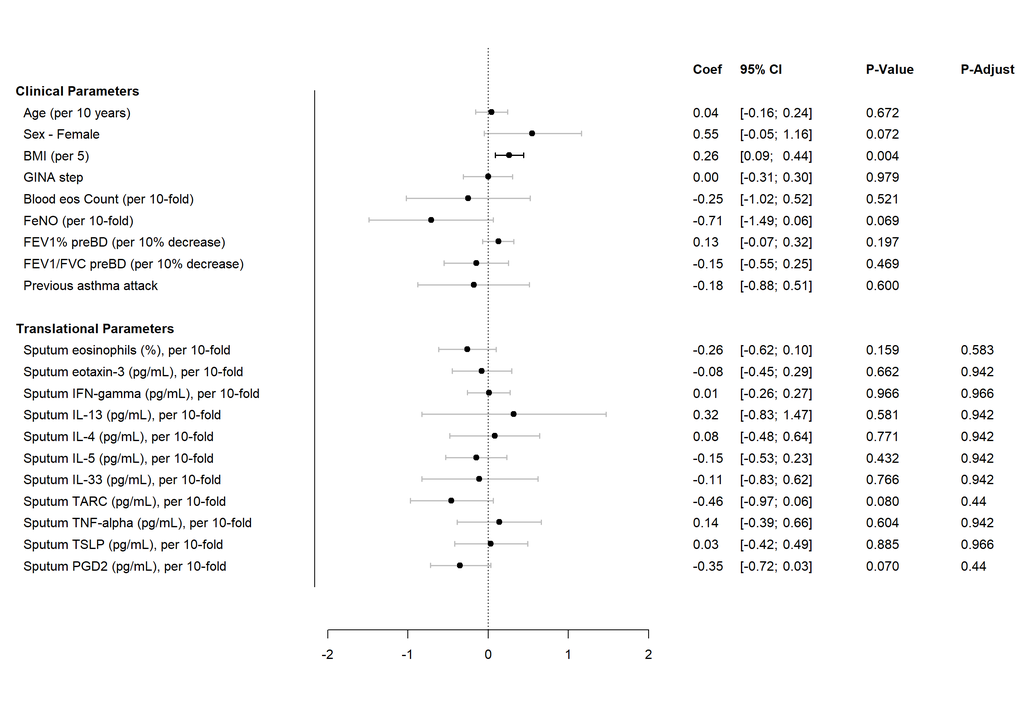

### BOOST

[figure not shown]

### FeNO

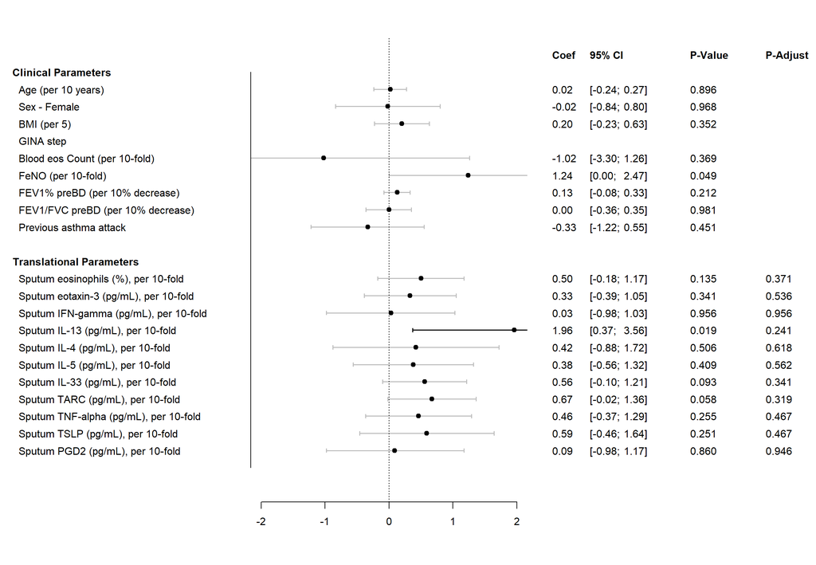

### RASP-UK

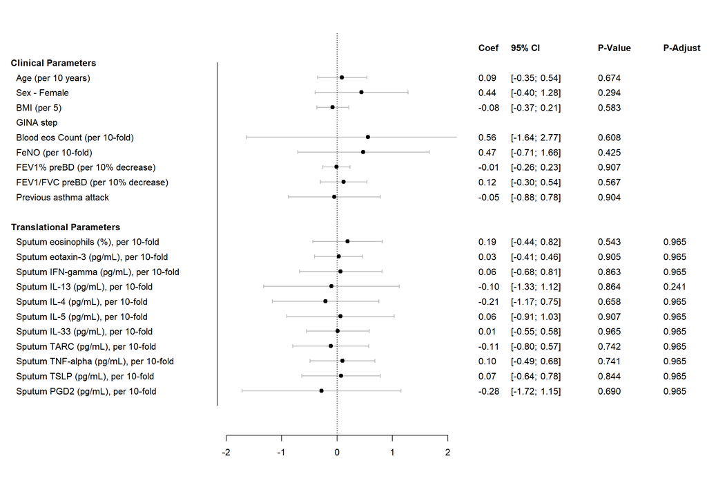

### FeNO + RASP-UK

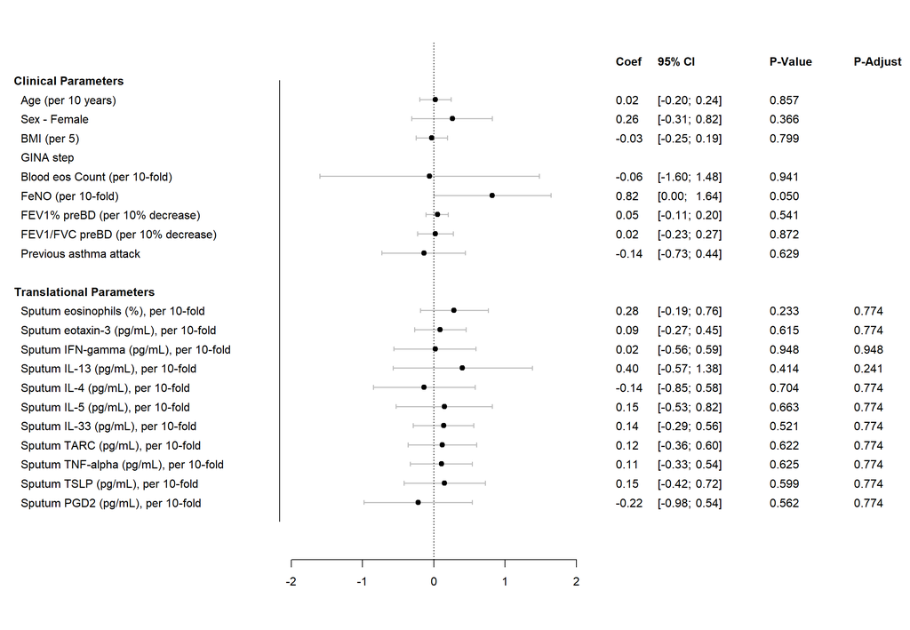

### Oracle imputed full

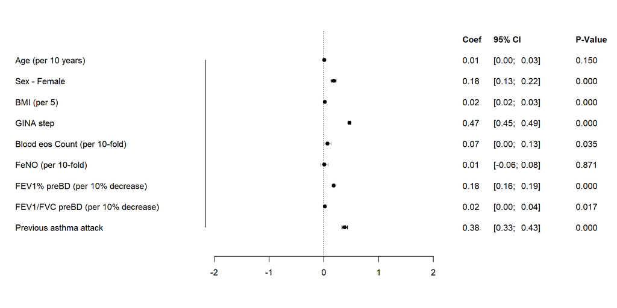

### Oracle imputed Any ACQ

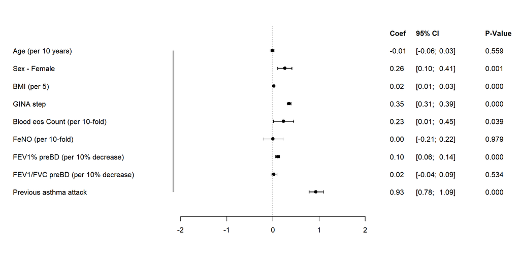

## Multivariable

2 regressions : one based on all Clinical Parameters and one based on all Translational Parameters. All clinical parameters are included in the same multivariable models, same for translational parameters.

ORACLE studies are adjusted for additionnal parameters. Two versions on Forest Plot are given ; One showing only the ‘main’ predictors and the other one showing every variables included.

### PRISMA

Adjusted for blood eosinophils, FeNO, and FEV1% predicted

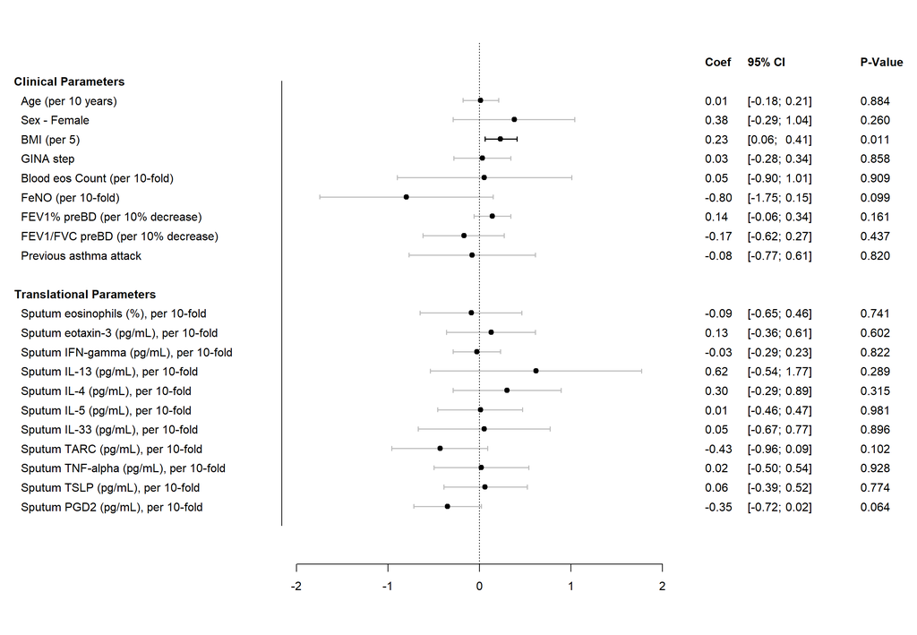

### BOOST

Adjusted for blood eosinophils, FeNO, and FEV1% predicted

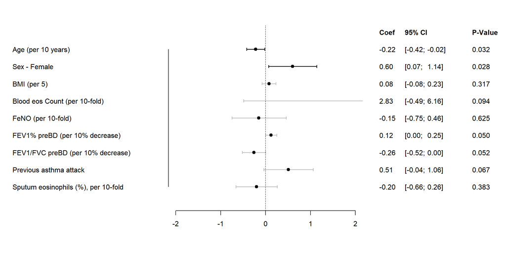

### FeNO

The variable Sp_Eos_optimised was not include because missing = 59%

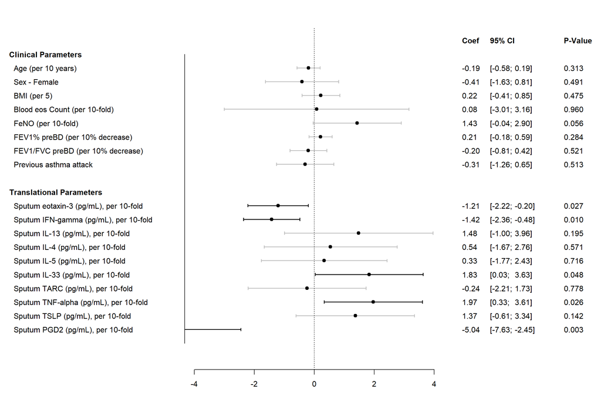

### RASP-UK

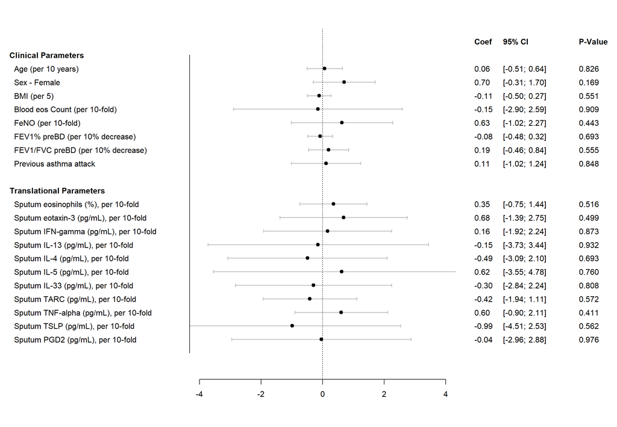

### FeNO + RASP-UK

Adjusted for blood eosinophils, FeNO, and FEV1% predicted

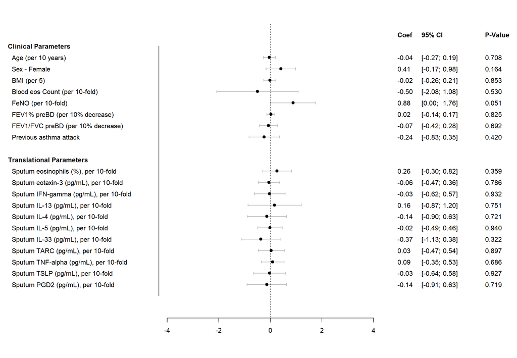

### Oracle imputed full

Enrolled trial is considered in the model.

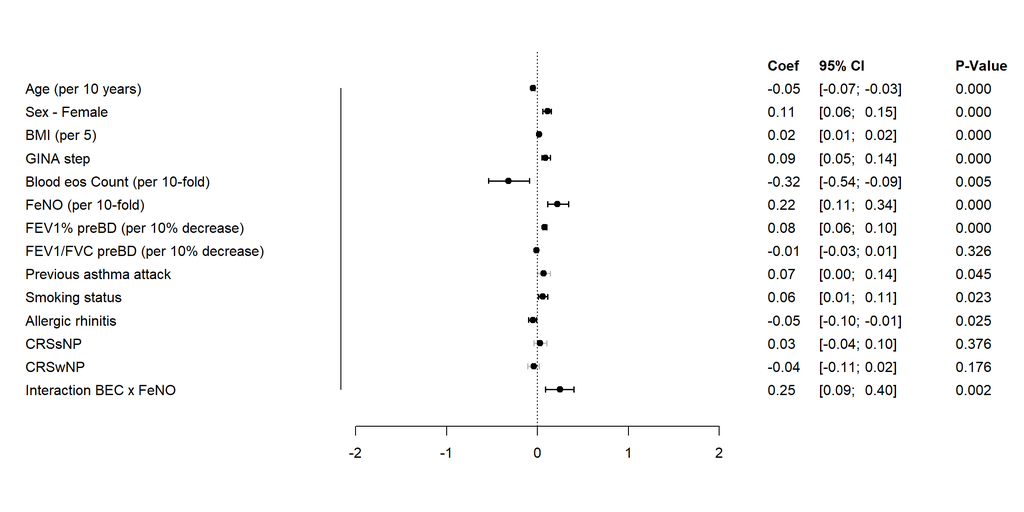

### Oracle imputed Any ACQ

Enrolled trial is considered in the model.

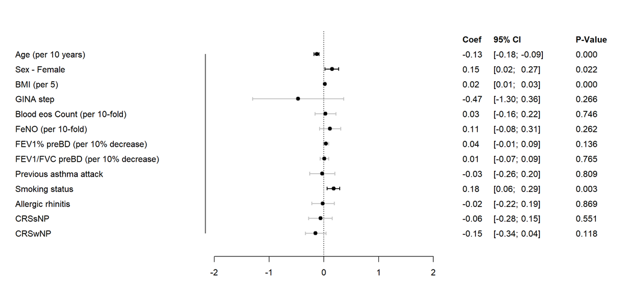

## Master

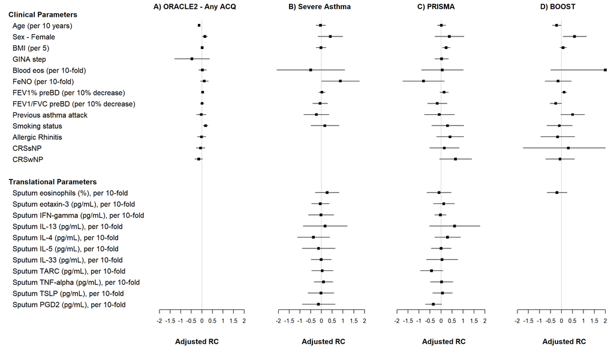

# Forestplot : Subgroups

## Oracle Dream

### Unadjusted

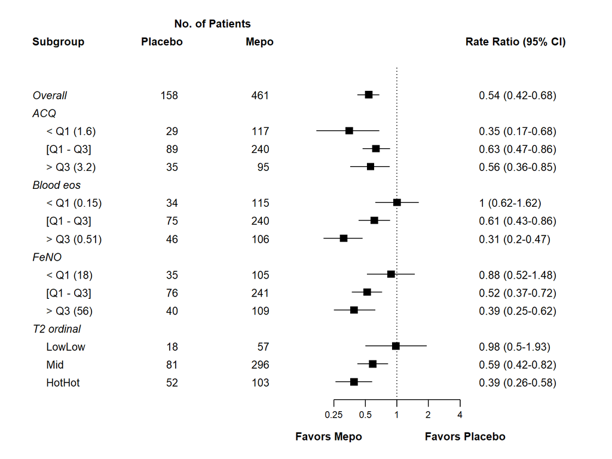

### Adjusted

Adjusted for same variables as SPLINE curves (Full multivariable). When possible interaction of FeNO and BEC were included. For T2, need to remove BEC and FeNO from model.

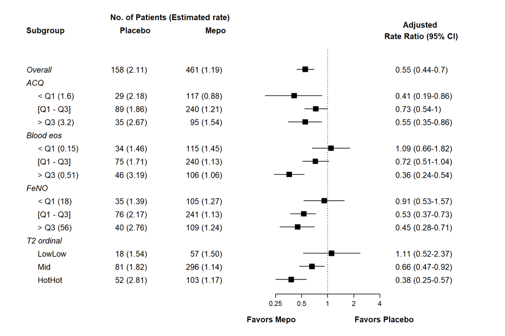